# Peer-graded Assignment: Course Project 1

Andrea Ballestero

6/27/2020

# Analysis of activity monitoring data

### Loading and preprocessing the data

```r
activity <- read.csv("~/R/Coursera/ProgAssign5_1/activity.csv")
```

### What is the mean total number of steps taken per day?

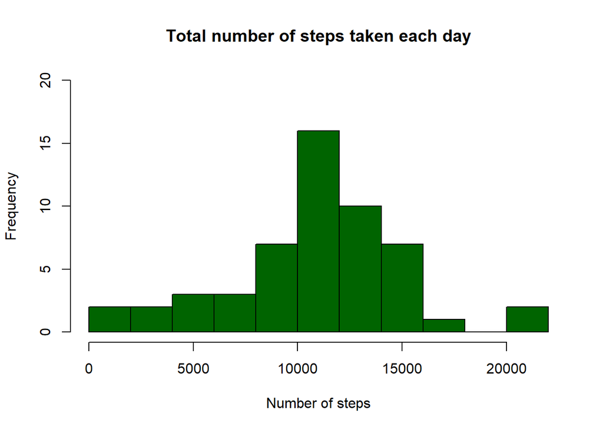

```r
library(dplyr)
total_steps <- summarise(group_by(activity, date), total = sum(steps, na.rm = FALSE))

hist(total_steps$total, breaks = 8,
     xlim = c(0, 22000), col = "dark green",
     main = "Total number of steps taken each day",
     xlab = "Number of steps",
     ylim = c(0, 20))
```

```r
library(formattable)
mean_steps <- comma(mean(total_steps$total, na.rm = TRUE), digit = 2)
median_steps <- comma(median(total_steps$total, na.rm = TRUE), digit = 2)
```

The mean of the total number of steps taken per day is 10,766.19 and the median of the total number of steps taken per day is 10,765.00.

### What is the average daily activity pattern?

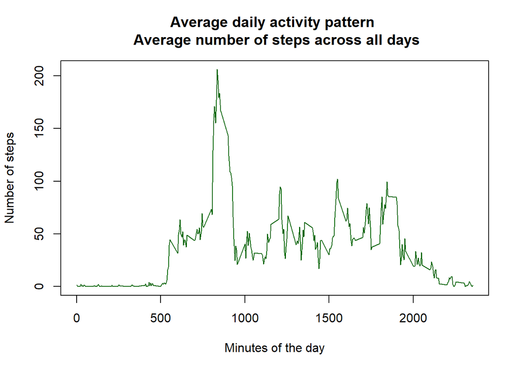

```r
library(lubridate)
activity <- mutate(activity, date = date(date))
five_min <- summarise(group_by(activity, interval), total = mean(steps, na.rm = TRUE))
five_min <- mutate(five_min, mean_min = comma(total, digits = 2))

plot(five_min$interval, five_min$mean_min, type = "l",
     col = "dark green",
     main = "Average daily activity pattern \n Average number of steps across all days",
     xlab = "Minutes of the day",
     ylab = "Number of steps")
```

```r
max_steps <- max(five_min$mean_min)
interv_max <- five_min[five_min$mean_min == max_steps, 1]
interv_max2 <- interv_max + 5
```

The 5-minute interval that contains the maximum number of steps is 835 - 840.

### Imputing missing values

```r
na <- activity[is.na(activity) == TRUE,]
dim_na <- dim(na)
rows_na <- comma(dim_na[1], digits = 0)
```

The total number of missing values in the dataset is 2,304.

```r
days_na <- unique(na$date)
```

The days which have missing values are: 2012-10-01, 2012-10-08, 2012-11-01, 2012-11-04, 2012-11-09, 2012-11-10, 2012-11-14, 2012-11-30.

The following procedure fills the empty data by completing it with the mean for the 5-minute interval and creates a new database called new_data:

```r
days_na <- data.frame(rep(unique(na$date), 472))
colnames(days_na) <- "days"
days_na <- arrange(days_na, days)
days_na <- mutate(days_na, interval = rep(seq(0, 2355, 5), 8))
days_na <- right_join(days_na, five_min, "interval")
colnames(days_na) <- c("date", "interval", "steps2", "steps")
new_data <- bind_rows(activity, days_na)
new_data <- select(new_data, c("steps", "date", "interval"))
new_data <- new_data[!is.na(new_data$steps),]
new_data <- arrange(new_data, date)
new_data <- mutate(new_data, steps = comma(steps, digits = 2))
```

The histogram of the total number of steps taken each day with the new data base is the following:

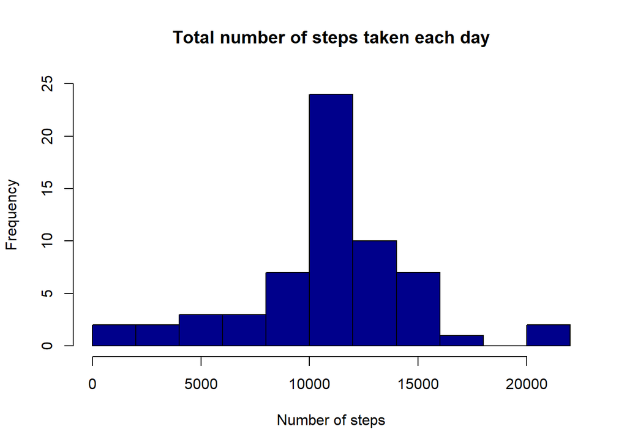

```r
new_total_steps <- summarise(group_by(new_data, date), total = sum(steps))

hist(new_total_steps$total, breaks = 8,
     xlim = c(0, 22000), col = "dark blue",
     main = "Total number of steps taken each day",
     xlab = "Number of steps",
     ylim = c(0, 25))
```

```r
new_mean_steps <- comma(mean(new_total_steps$total), digit = 2)
new_median_steps <- comma(median(new_total_steps$total), digit = 2)

diff <- new_median_steps - median_steps
perc <- diff/median_steps*100
```

Now, the mean of the total number of steps taken per day is 10,766.19 and the median of the total number of steps taken per day is 10,766.19.

### Are there differences in activity patterns between weekdays and weekends?

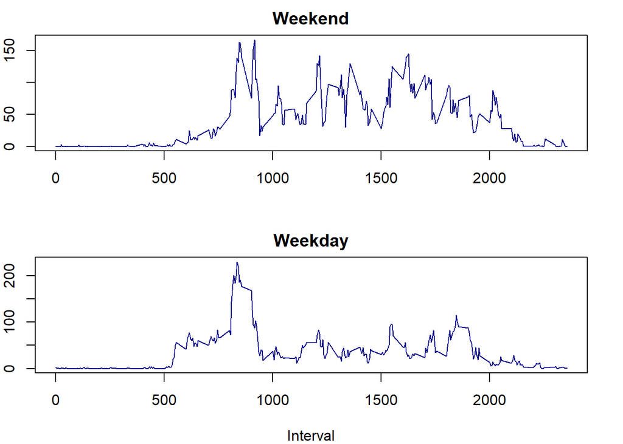

```r
new_data <- mutate(new_data, day = weekdays(date))
new_data <- mutate(new_data, factor_date = if_else(day %in% c("Saturday", "Sunday"), "weekend", "weekday"))

weekday_df <- new_data[new_data$factor_date == "weekday",]
weekend_df <- new_data[new_data$factor_date == "weekend",]

weekday_five_min <- summarise(group_by(weekday_df, interval), total = mean(steps))
weekday_five_min <- mutate(weekday_five_min, mean_min = comma(total, digits = 2))

weekend_five_min <- summarise(group_by(weekend_df, interval), total = mean(steps))
weekend_five_min <- mutate(weekend_five_min, mean_min = comma(total, digits = 2))

par(mar = c(4, 2, 2, 2))
par(mfrow = c(2, 1))

plot(weekend_five_min$interval, weekend_five_min$mean_min, type = "l",
     col = "dark blue",
     main = "Weekend",
     xlab = "",
     ylab = "Number of steps")

plot(weekday_five_min$interval, weekday_five_min$mean_min, type = "l",
     col = "dark blue",
     main = "Weekday",
     xlab = "Interval",
     ylab = "Number of steps")
```

As seen on the panel plot, there’s more movement on weekends than on weekdays.